# Visualizing Linguistic Data

Domain patterns for prominence research

Job Schepens

Universität zu Köln

18 November 2026

## Overview

### What this deck adds

The first two decks teach the grammar and the machinery. This one covers the **data shapes of prominence research**:

1. **Contours and spaces** — F0 over time, vowel formants
2. **Individuals** — speaker and item effects, not only means
3. **Ordinal, proportion, and count data** — ratings, accuracy, corpora
4. **Models and data care** — coefficient plots, posteriors, fonts, disclosure, missing data

### Plan

- **Contours and spaces:** 20 min
- **Individuals:** 10 min
- **Ratings and counts:** 20 min
- **Models and data care:** 20 min

*Total: 70 minutes.*

**Relationship to the other decks**

`slides.qmd` covers the grammar and integrity; `slides-advanced.qmd` covers scales, models, and publication. Everything here assumes those two.

**Examples:** simulated data, marked as such in each subtitle, plus `data/prominence_trials.csv` for the coefficient plot.

**Prerequisites:** the basic workshop or equivalent experience with `ggplot2`.

## Part I: Contours and spaces

### After this part: plot a trajectory without lying

## F0 contours over time

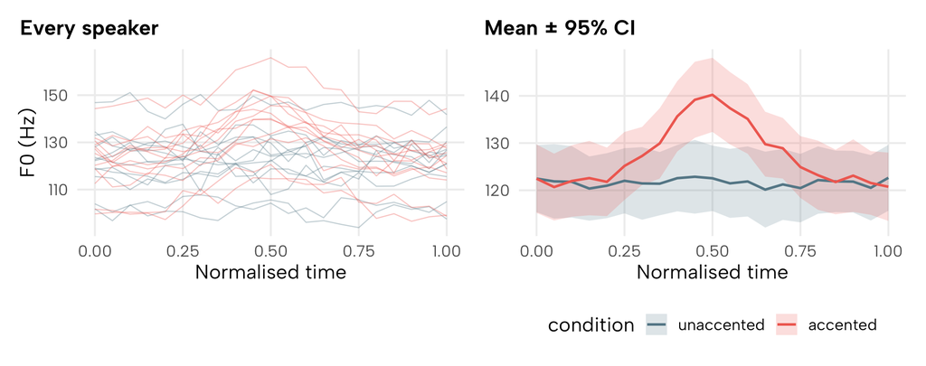

- **Normalise time** per token before averaging; raw milliseconds are not comparable across segments.
- Draw **every speaker** thin and the summary thick; a bar of means hides the trajectories.
- The band is a CI for the **mean contour**, not for a new speaker.
- Facet by condition or colour by it, but keep the same y scale.
- Say whether the contour is raw, z-scored per speaker, or in semitones.
- Simulated here; the code is identical on real tracks.

## Difference curves

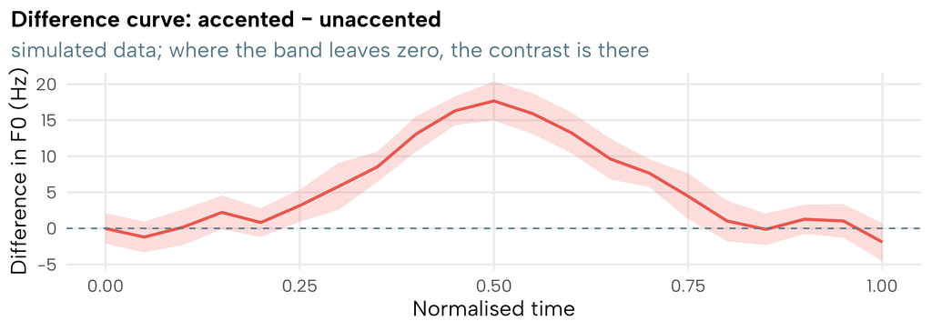

- A difference curve answers **where** an effect lives, not only whether it exists.
- The zero line is the null; the band is the uncertainty about the mean difference.
- Normalise time first, then subtract within speaker and item.
- In papers, add a horizontal bar marking the window used for analysis.
- Prefer this to two separate mean plots whose scales invite misreading.
- The same recipe works for ERP amplitudes, gaze proportions, and intensity.

## Vowel spaces

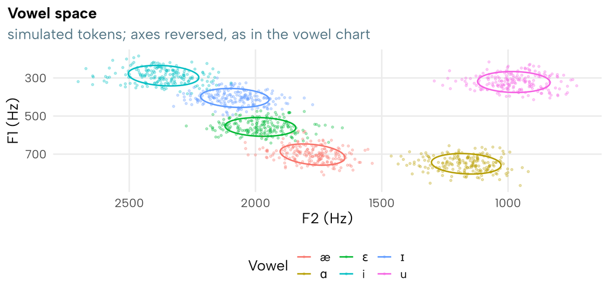

## Part II: Individuals

### After this part: show both speakers and items

## Speaker and item effects

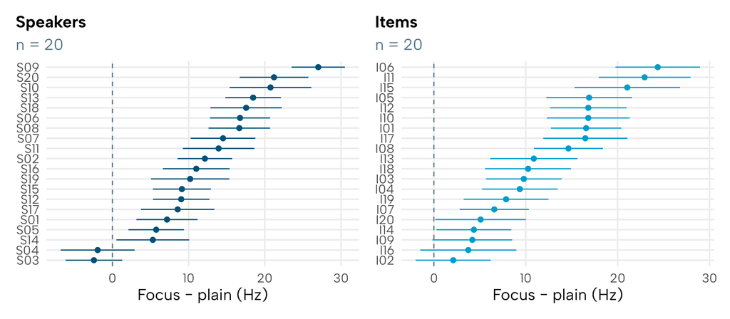

- A mean ± SE collapses **two** variance sources: who was measured (speakers) and what was measured (items).
- Caterpillar plots show both: order by size, show the interval, keep the zero line.
- The same layout works for random effects from `lme4` or posterior draws from `brms`.
- If the effect is consistent for speakers but not items, the generalisation is about speakers, not words.
- Show the raw per-unit estimates before the model; the model is a summary, not a substitute.
- Facet by condition when there are more than two.

## Part III: Ratings and counts

### After this part: plot the distribution, not only the mean

## Ordinal ratings

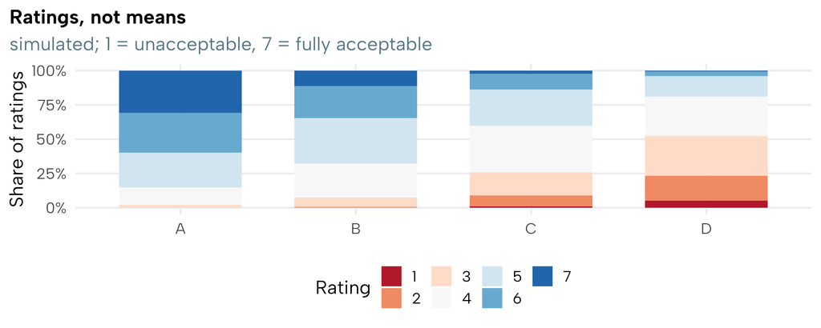

- A mean of 4.0 can come from “everyone is neutral” or “half love it, half hate it”. The stacked distribution separates them.
- Keep the ordinal scale; do not treat 1–7 as interval data in the figure.
- A diverging palette centred on the neutral category makes the direction visible.
- For models, ordinal regression gives predicted **probabilities** per category; plot those rather than a single mean.
- Report the number of raters and items; the share is only as stable as the sample.
- A stacked bar and a density of ratings tell the same story; choose one and label it.

## Proportions with honest intervals

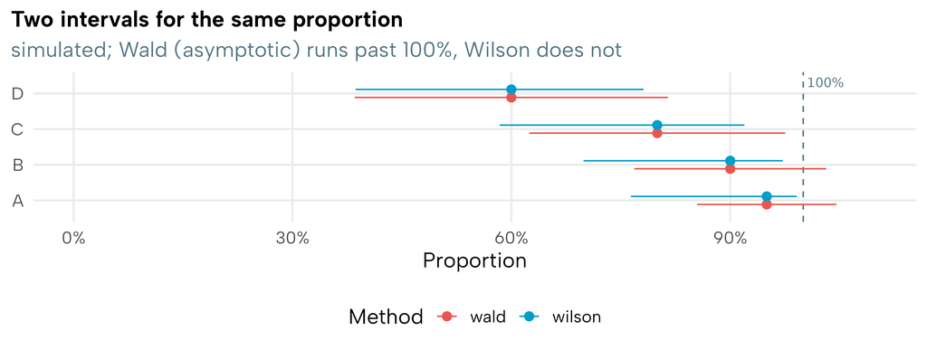

- Proportions are bounded; the Wald interval is not. Near 0 or 1 it can cross the boundary and collapse to zero width.
- **Wilson** (or Clopper–Pearson) intervals stay inside and are asymmetric where they should be.
- A logit axis (`scale_y_continuous(trans = "logit")`) spreads the ends; name the scale.
- Report *n* per cell; an interval on 5 trials is mostly the prior, not the data.
- For repeated measures, the interval must respect the design (see the intervals slide in the advanced deck).
- Same advice for accuracy, agreement rates, and proportions of annotated categories.

## Corpus counts

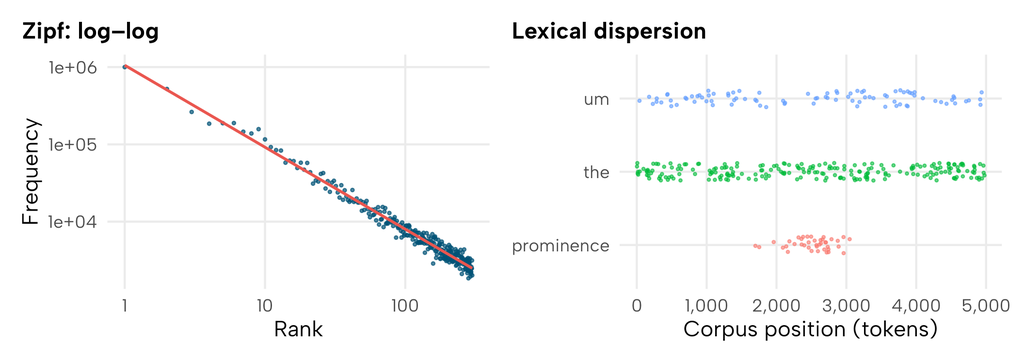

- Frequencies span orders of magnitude: **log–log** axes turn Zipf’s law into a line and keep rare words visible.
- A straight line on log–log axes is a description, not a law; fit it and say so.
- Counts have no upper bound, so bars of raw counts invite wrong comparisons across corpora.
- Frequency alone hides **clustering**: a word can be frequent but concentrated in one register or speaker.
- Dispersion plots put occurrences in corpus order; x is position, y is the word.
- Report both frequency and dispersion when the claim is about typicality.

## Part IV: Models and data care

### After this part: report the model, protect the data

## Coefficient plots

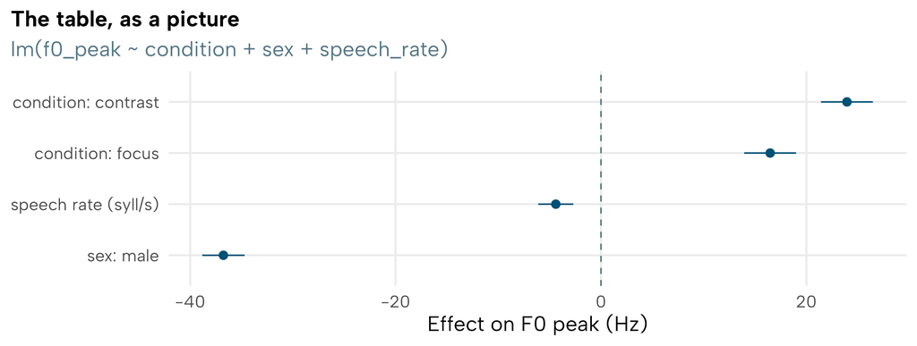

- A coefficient plot is a forest plot for one model: estimates on the x-axis, terms on the y-axis, intervals and a zero line.
- Order terms by size; readers compare lengths, which is the most accurate encoding.
- Keep the units in the axis label; a coefficient without units is unreadable.
- For interactions, a coefficient plot is not enough; plot predictions or slopes (advanced deck).
- For models on a link scale, say whether the axis is log-odds, probability, or the response.
- The same layout serves `broom`, `modelsummary`, and posterior draws.

## Posterior distributions

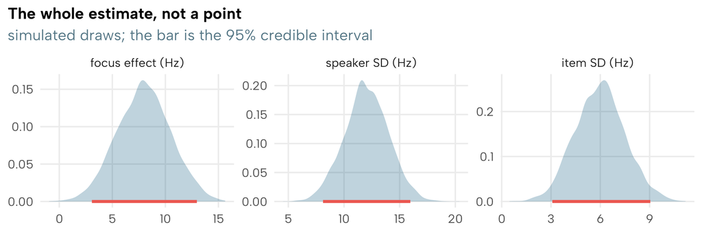

- A posterior is a distribution; a point estimate and an interval are summaries of it.
- Densities show skew and multimodality that an interval hides.
- `ggdist` provides half-eye, ridgeline, and dot-interval geoms for this; the hand-built version needs no extra package.
- For a decision, shade a **ROPE** and report the mass inside it.
- Mixed-model variance components (speaker SD, item SD) deserve a plot too; they are often the story.
- Say whether the draws are from a model, a bootstrap, or a simulation.

## IPA, scripts, and fonts

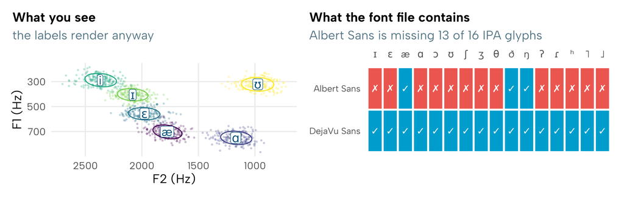

- IPA, combining diacritics, tone letters, and non-Latin scripts depend on the **font**, not on R.
- `ragg` **falls back silently**: the left panel looks right because the missing glyphs come from another font. The figure is fine; the typography is not.
- Check coverage with `systemfonts::glyph_info()`; an index of `0` means the glyph is absent.
- For PDF, embed fonts (`cairo_pdf`, `svglite`) or the glyphs will be substituted.
- Pick a font with wide coverage: DejaVu Sans, Noto Sans, Charis SIL, Doulos SIL.
- Set the family per layer when scripts differ: `geom_text(family = "Noto Sans")`.
- Put IPA in **labels and alt text**, not only in the legend.
- If a glyph still fails, spell it out in the caption.

**Test on the target**

Render the actual PDF or PNG and open it on the machine you will present from. The viewer lies.

## Small N and disclosure

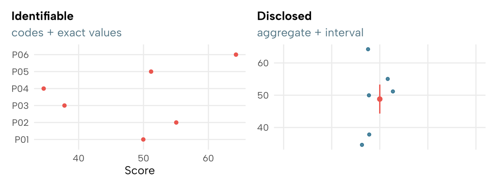

- Participant codes, exact dates, and rare combinations can re-identify people, especially in small samples.
- Do not put raw IDs, session dates, or free-text responses in figures.
- Suppress small cells; report aggregates with *n*.
- Audio examples need consent for **sharing**, not only for collection.
- Keep the analysis reproducible with pseudonymous keys stored separately.
- For qualitative examples, quote with permission and remove identifying details.
- Check your ethics approval and the CRC’s data policy; when in doubt, aggregate.

## Missing data and exclusions

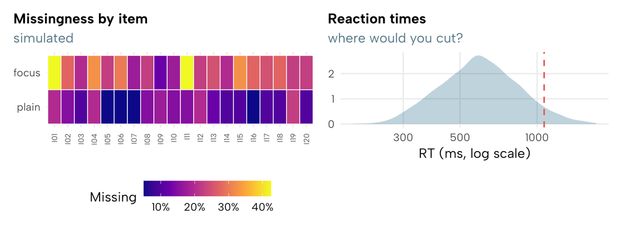

- Show **where** data are missing, not only how much: a condition that loses trials changes the estimate.
- Report *n* per cell and the exclusion rule; a symmetry assumption is a claim.
- Compare results with and without exclusions (sensitivity), and say so.
- Show the distribution before cutting outliers; a density with a threshold is honest.
- RTs are skewed: log axes and medians, not means of raw milliseconds.
- Never drop “outliers” silently; the figure should make the rule visible.

## Five takeaways

1. **Match the figure to the data shape.** Time within trial, formants per token, ordinal ratings, and corpus positions each need their own idiom.
2. **Show individuals.** Every-speaker lines, caterpillars, and per-unit effects prevent over-generalising from a mean.
3. **Distributions beat means** for ratings and proportions; intervals must respect bounds and design.
4. **Plot the model.** Coefficients and posteriors are more informative than tables, and variance components are part of the story.
5. **The output is part of the analysis.** Fonts, disclosure, missingness, and exclusions are scientific choices, not formatting.

**The grammar travels**

The same `ggplot2` grammar covers all of this. What changes is the data shape and the question — not the layers, scales, or facets you already know.

**Next steps**

- Re-plot one figure from your own project using the shape of its data.
- Try a difference curve, a caterpillar plot, or a coefficient plot this week.
- Check one figure for font coverage and disclosure before the next talk.

## Extensions: distributions and labels

Most of what this deck builds by hand has a maintained extension. Install only what you need: every package is a dependency you have to keep working.

| Package | What it adds | Where it helps in prominence work |
| --- | --- | --- |
| [`ggdist`](https://cran.r-project.org/package=ggdist) | Half-eye, dot, and gradient intervals; ROPE shading | Posterior draws, per-speaker effects, anything with a distribution |
| [`ggridges`](https://cran.r-project.org/package=ggridges) | Ridgeline densities | F0 or duration distributions per speaker, stacked and comparable |
| [`ggbeeswarm`](https://cran.r-project.org/package=ggbeeswarm) | Quasirandom and swarm jitter | Ratings and accuracy with few observations per cell |
| [`ggrepel`](https://cran.r-project.org/package=ggrepel) | Labels that push away from each other | Vowel labels, speaker IDs, item names |
| [`ggtext`](https://cran.r-project.org/package=ggtext) | Markdown and HTML in labels | *Italics*, F<sub>0</sub>, IPA, coloured words in titles |
| [`ggpmisc`](https://cran.r-project.org/package=ggpmisc) | Equations, tables, and annotations as layers | Model equations and small tables inside a panel |
| [`ggfittext`](https://cran.r-project.org/package=ggfittext) | Text that shrinks to fit its box | Labels inside bars and tiles |

**Start with two**

`ggdist` and `ggtext` cover most of what this deck builds by hand. Add `ggbeeswarm` if your cells are small, and `ggrepel` the first time two vowel labels collide.

## Extensions: layout, categories, colour

| Package | What it adds | Where it helps in prominence work |
| --- | --- | --- |
| [`ggforce`](https://cran.r-project.org/package=ggforce) | `facet_zoom()`, `geom_mark_ellipse()`, `geom_sina()` | Zoom into a crowded vowel region without changing the scale |
| [`ggnewscale`](https://cran.r-project.org/package=ggnewscale) | A second colour or fill scale in one plot | Points coloured by vowel plus tiles shaded by probability |
| [`ggalluvial`](https://cran.r-project.org/package=ggalluvial) | Alluvial and Sankey flows | How annotation categories change across turns or raters |
| [`ggmosaic`](https://cran.r-project.org/package=ggmosaic) | Mosaic plots | Two categorical variables, e.g. condition × response category |
| [`ggseqplot`](https://cran.r-project.org/package=ggseqplot) | Sequence plots, built on `TraMineR` | Gaze, gesture phase, or annotation state over time |
| [`ggupset`](https://cran.r-project.org/package=ggupset) | UpSet plots | Which participants or items fall in which condition sets |
| [`ggbreak`](https://cran.r-project.org/package=ggbreak) | Axis breaks | A gap you must show — label it, or use a facet instead |
| [`scico`](https://cran.r-project.org/package=scico) | Scientific, perceptually uniform palettes | Sequential and diverging scales that survive a projector |
| [`ggokabeito`](https://cran.r-project.org/package=ggokabeito) | Okabe–Ito colour-blind-safe palette | Categorical scales for talks and print |

**Two to treat with care**

`ggbreak` hides part of the axis; a reader who skips the label will misread the figure. `ggalluvial` and `ggseqplot` are excellent but assume a data shape (one row per transition or per time point) that most acoustic data frames do not have yet — reshape first, then plot.

## Domain packages, and how to choose

### Acoustic and phonetic

- [`phonR`](https://cran.r-project.org/package=phonR) — Lobanov and other normalisations, vowel plotting helpers
- [`vowels`](https://cran.r-project.org/package=vowels) — reference vowel data and normalisation methods
- [`wrassp`](https://cran.r-project.org/package=wrassp) — F0, formants, and intensity from the ASSP library
- [`emuR`](https://cran.r-project.org/package=emuR) — query and plot from speech databases
- [`praatpicture`](https://cran.r-project.org/package=praatpicture) — Praat-style annotation plots built on ggplot2

### Corpus and text

- [`quanteda`](https://cran.r-project.org/package=quanteda) — corpus statistics that feed the plots
- [`tidytext`](https://cran.r-project.org/package=tidytext) — token and frequency tables in tidy shape
- [`lingtypology`](https://cran.r-project.org/package=lingtypology) — typological features and maps

The next two slides run `phonR`, `vowels`, `quanteda`, and `tidytext` on real data.

### How to choose an extension

- **Does it still build?** Check the CRAN checks page and the last release date before you depend on it in a paper.
- **Does it compose with the grammar?** A geom or scale you can place in a pipeline is safer than a function that returns a finished picture.
- **Can you read the source?** Most extensions are a few hundred lines; the ones that are not are the ones that surprise you.
- **Prefer the layer you understand.** A hand-built `geom_segment()` you can explain beats a helper you cannot.
- **For a paper, fewer dependencies.** Reproducibility is easier when the figure needs three packages, not thirteen.

**The rule of thumb**

If the extension saves you a paragraph of explanation in the methods section, keep it. If it hides a choice you would have to defend, build the layer yourself.

## In practice: acoustic data

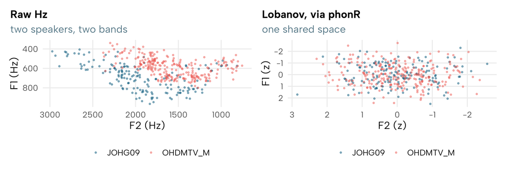

- `vowels::ohiovowels` is real data: 2 speakers, 24 vowel classes, 426 tokens after filtering.
- Raw speaker means differ by **105 Hz in F1** and **340 Hz in F2**; after Lobanov both are exactly 0.
- `phonR::normLobanov()` returns a plain data frame, so the plotting grammar does not change.
- `phonR::vowelMeansPolygonArea()` gives vowel-space area: 146,000 vs 74,000 Hz² here — a size difference, not a vowel difference.
- Filter before you normalise: a cell with one token has no SD, and the function returns `NaN` rather than warning.
- `vowels::vowelplot()` is the package’s own base-graphics plot; use it to check, then rebuild in ggplot2.

## In practice: corpus data

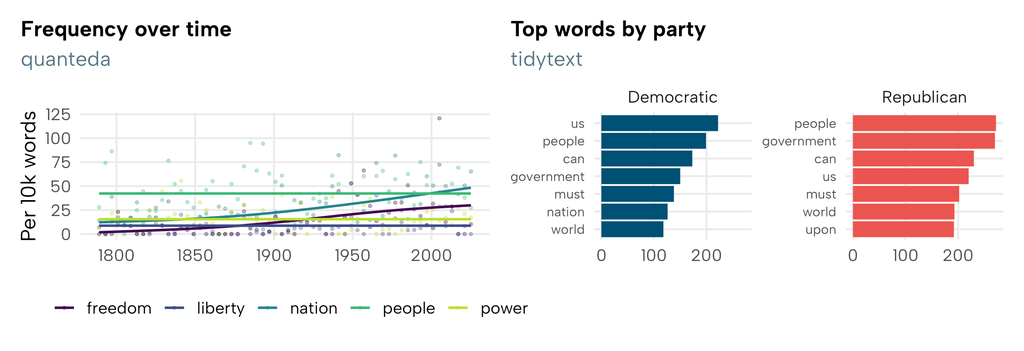

- `quanteda` gives a document-feature matrix; `convert()` turns it into a data frame that ggplot2 can draw.
- Divide by **document length** (`ntoken()`), not by the count of the words you selected — the first version of this figure did the latter and produced nonsense.
- `tidytext::unnest_tokens()` gives one row per token, the shape `dplyr` verbs expect.
- `reorder_within()` + `scale_y_reordered()` are what make per-facet ordering work; without them both facets share one order.
- `anti_join(get_stopwords())` is a one-line stop-word filter that keeps the pipeline readable.
- Both packages stop at the data frame. The grammar, the theme, and the honesty rules are unchanged.

## Further reading

### Time, space, and models

- [ggplot2 book](https://ggplot2-book.org/) chapters on layers and scales (Wickham et al., 2024)
- Wood, *Generalized Additive Models* — for contour smooths (Wood, 2017)
- [`mgcv`](https://cran.r-project.org/package=mgcv) and [`gratia`](https://gavinsimpson.github.io/gratia/) for GAMM plots
- [`ggdist`](https://mjskay.github.io/ggdist/) for posterior and uncertainty geoms (Kay, 2024)
- [`marginaleffects`](https://marginaleffects.com/) for predictions and slopes
- [ggplot2 extension gallery](https://exts.ggplot2.tidyverse.org/gallery/) — browse by geom, scale, or task

### Linguistics and data care

- [`phonTools`](https://cran.r-project.org/package=phonTools) and [`praatpicture`](https://cran.r-project.org/package=praatpicture) for acoustic data in R
- [`naniar`](https://naniar.njtierney.com/) for missing-data visualisation
- [`viridis`](https://sjmgarnier.github.io/viridis/) and [ColorBrewer](https://colorbrewer2.org/) for palettes
- [`reprex`](https://reprex.tidyverse.org/) for asking questions with a reproducible example

## Acknowledgements

This deck was written for the SFB 1252 “Prominence in Language” workshop series.

The examples are simulated unless stated otherwise; `data/prominence_trials.csv` is generated by `scripts/make-prominence-data.R` and is not a measurement of any real speaker.

**Contact:** job.schepens@uni-koeln.de

**Materials:** [SFB 1252 talks repository](https://github.com/SFB1252/talks)

**Reuse**

- Slides: CC BY 4.0
- Code: MIT
- Data: see `data/README.md`

If you reuse the slides, keep the attribution.

**AI assistance: heavy.** Text and structure were primarily drafted with DeepSeek v4.1 Flash via SAIA (AcademicCloud) from human-provided material, then reviewed and edited by the author. [What this means](https://sfb1252.github.io/talks/about/ai-assistance-levels/)

**Companion decks:** basic · advanced

Kay, M. (2024). Ggdist: Visualizations of distributions and uncertainty in the grammar of graphics. *IEEE Transactions on Visualization and Computer Graphics*, *30*(1), 414–424. https://doi.org/10.1109/TVCG.2023.3327195

Wickham, H., Navarro, D., & Pedersen, T. L. (2024). *ggplot2: Elegant graphics for data analysis* (3rd ed.). Springer. https://doi.org/10.1007/978-3-031-64720-3

Wood, S. N. (2017). *Generalized additive models: An introduction with r* (2nd ed.). Chapman; Hall/CRC.